# Lesson 6

# We’ve put some code below to get you started.

# The first plot should be a histogram of price

# and the second plot should transform

# the price variable using log10.

# Set appropriate bin widths for each plot.

# ggtitle() will add a title to each histogram.

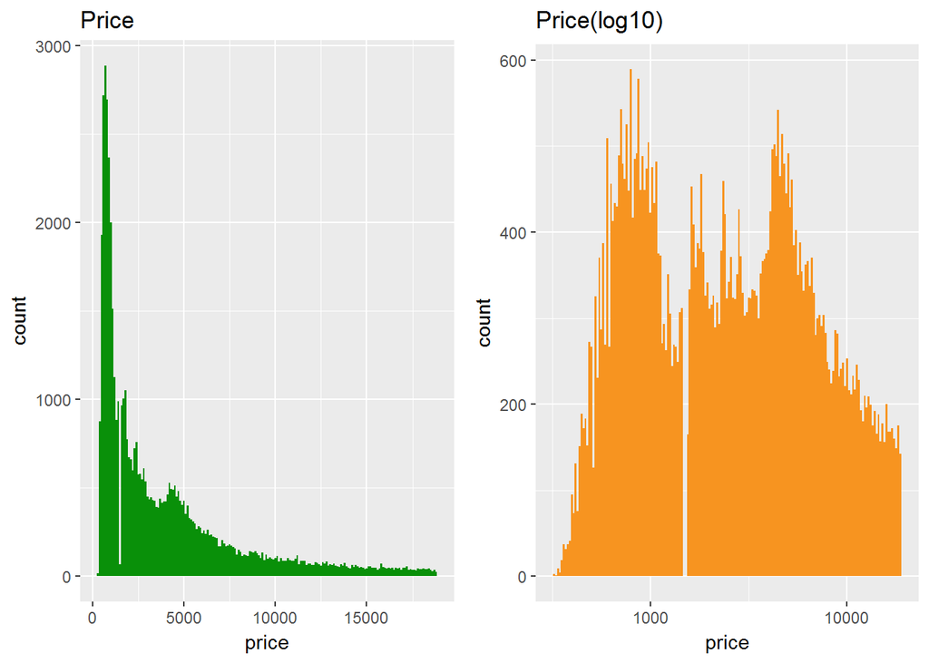

```r
plot1 <- qplot(data=diamonds, x=price, binwidth=100, fill=I('#099009')) +
  ggtitle('Price')
plot2 <- qplot(data=diamonds, x=price, binwidth=0.01, fill=I('#F79420')) +
  ggtitle('Price(log10)') +
  scale_x_log10()
library(gridExtra)
library(grid)
grid.arrange(plot1, plot2, ncol=2)
```

### Connecting Demand and Price Distributions

Notes:

### Scatterplot Transformation

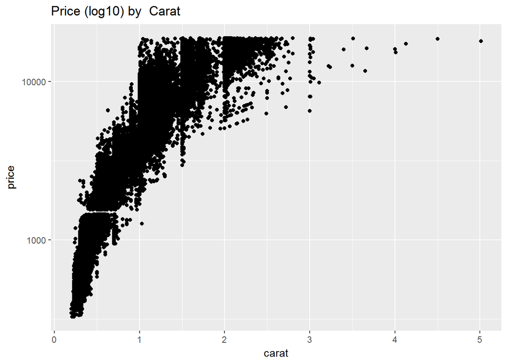

```r
qplot(carat, price, data=diamonds) +
  scale_y_continuous(trans=log10_trans()) +
  ggtitle('Price (log10) by  Carat')
```

### Create a new function to transform the carat variable

```r
cuberoot_trans = function() trans_new('cuberoot', transform = function(x) x^(1/3),
                                      inverse = function(x) x^3)
```

#### Use the cuberoot_trans function

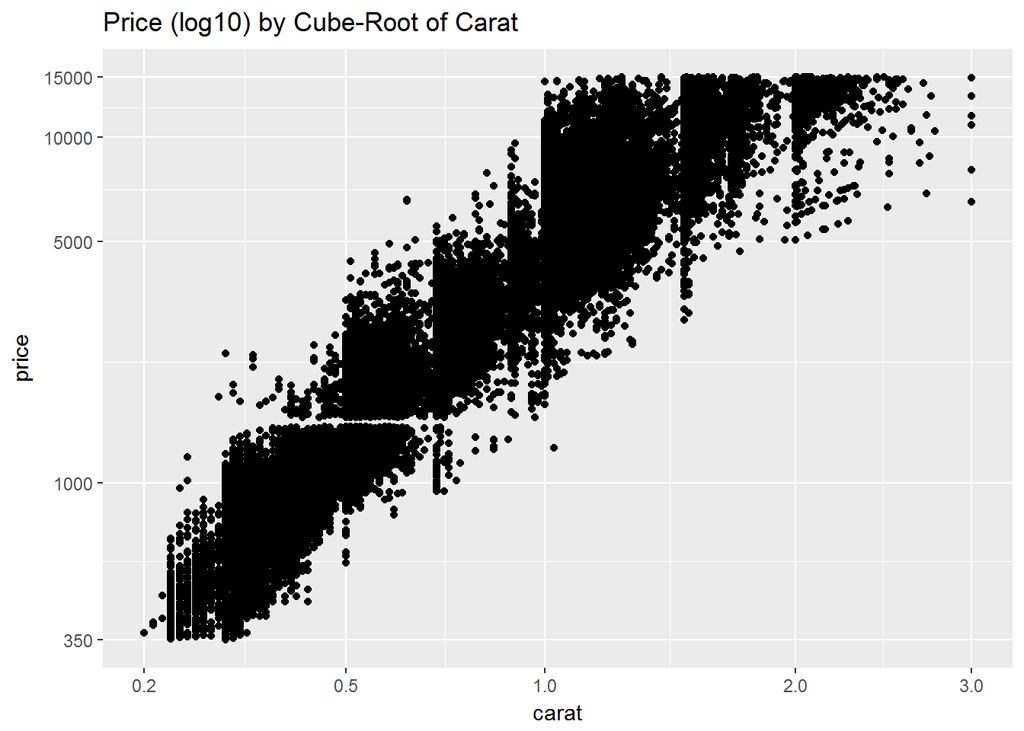

```r
ggplot(aes(carat, price), data = diamonds) +
  geom_point() +
  scale_x_continuous(trans = cuberoot_trans(), limits = c(0.2, 3),
                     breaks = c(0.2, 0.5, 1, 2, 3)) +
  scale_y_continuous(trans = log10_trans(), limits = c(350, 15000),
                     breaks = c(350, 1000, 5000, 10000, 15000)) +
  ggtitle('Price (log10) by Cube-Root of Carat')
```

### Overplotting Revisited

Multiple points taking same values, overlapping each other

```r
head(sort(table(diamonds$carat), decreasing=T))
```

```
##
##  0.3 0.31 1.01  0.7 0.32    1
## 2604 2249 2242 1981 1840 1558
```

```r
head(sort(table(diamonds$price), decreasing=T))
```

```
##
## 605 802 625 828 776 698
## 132 127 126 125 124 121
```

# Add a layer to adjust the features of the

# scatterplot. Set the transparency to one half,

# the size to three-fourths, and jitter the points.

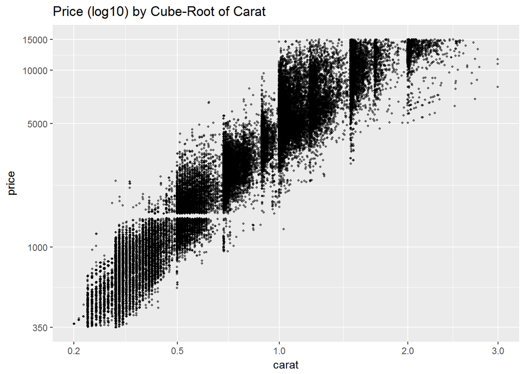

```r
ggplot(aes(carat, price), data = diamonds) +
  geom_point(alpha=0.5, size=0.75, position='jitter') +
  scale_x_continuous(trans = cuberoot_trans(), limits = c(0.2, 3),
                     breaks = c(0.2, 0.5, 1, 2, 3)) +
  scale_y_continuous(trans = log10_trans(), limits = c(350, 15000),
                     breaks = c(350, 1000, 5000, 10000, 15000)) +
  ggtitle('Price (log10) by Cube-Root of Carat')
```

### Other Qualitative Factors

Notes: alpha, size, and position inside geom_point(). To jitter the points, set position equal to “jitter”. ***

### Price vs. Carat and Clarity

# Adjust the code below to color the points by clarity.

# A layer called scale_color_brewer() has

# been added to adjust the legend and

# provide custom colors.

Alter the code below.

```r
# install and load the RColorBrewer package
#install.packages('RColorBrewer')
library(RColorBrewer)
```

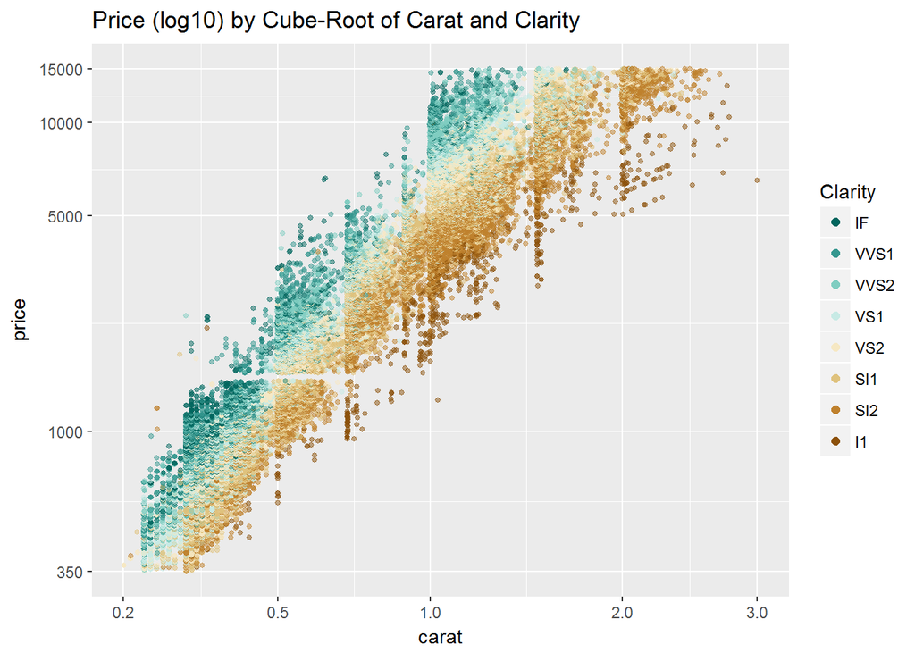

```r
ggplot(aes(x = carat, y = price, colour = clarity), data = diamonds) +
  geom_point(alpha = 0.5, size = 1, position = 'jitter') +
  scale_color_brewer(type = 'div',
    guide = guide_legend(title = 'Clarity', reverse = T,
    override.aes = list(alpha = 1, size = 2))) +
  scale_x_continuous(trans = cuberoot_trans(), limits = c(0.2, 3),
    breaks = c(0.2, 0.5, 1, 2, 3)) +
  scale_y_continuous(trans = log10_trans(), limits = c(350, 15000),
    breaks = c(350, 1000, 5000, 10000, 15000)) +
  ggtitle('Price (log10) by Cube-Root of Carat and Clarity')
```

### Clarity and Price

Response:

### Price vs. Carat and Cut

Alter the code below.

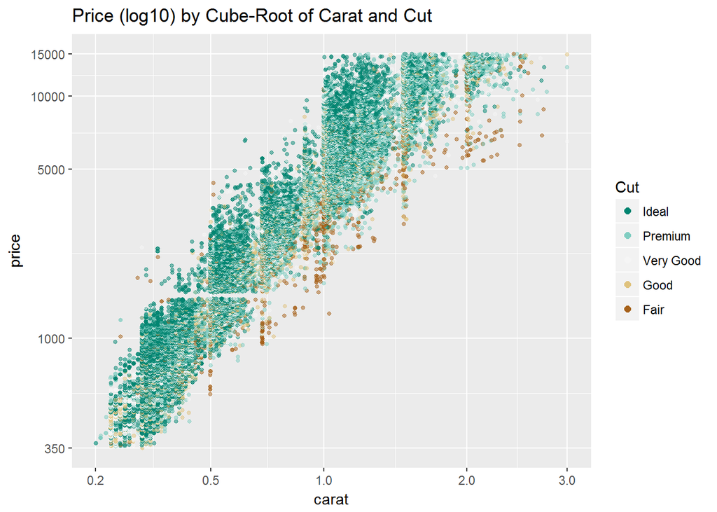

```r
ggplot(aes(x = carat, y = price, color = cut), data = diamonds) +
  geom_point(alpha = 0.5, size = 1, position = 'jitter') +
  scale_color_brewer(type = 'div',
                     guide = guide_legend(title = 'Cut', reverse = T,
                                          override.aes = list(alpha = 1, size = 2))) +
  scale_x_continuous(trans = cuberoot_trans(), limits = c(0.2, 3),
                     breaks = c(0.2, 0.5, 1, 2, 3)) +
  scale_y_continuous(trans = log10_trans(), limits = c(350, 15000),
                     breaks = c(350, 1000, 5000, 10000, 15000)) +
  ggtitle('Price (log10) by Cube-Root of Carat and Cut')
```

### Cut and Price

Response:

### Price vs. Carat and Color

Alter the code below.

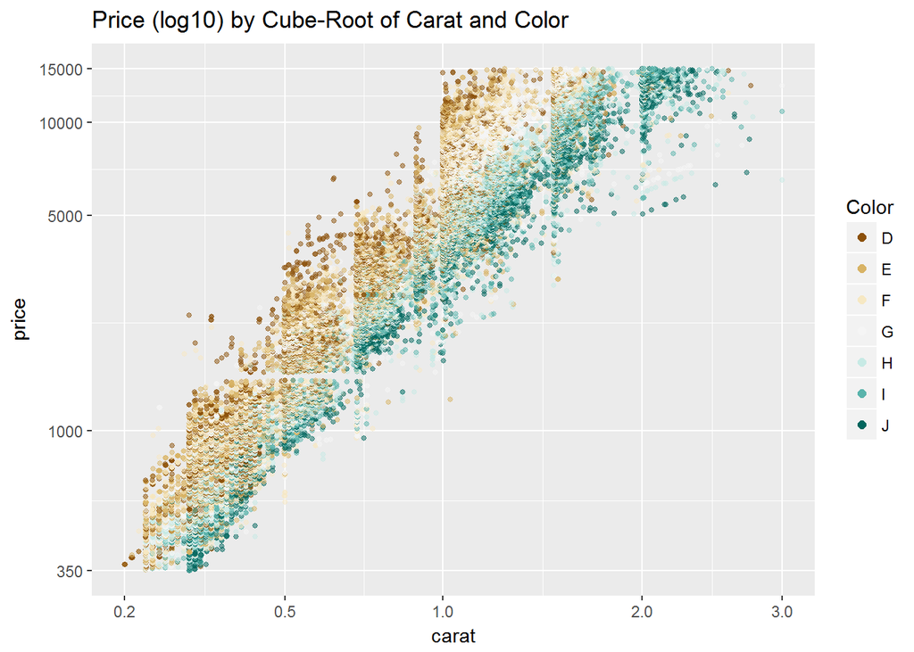

```r
ggplot(aes(x = carat, y = price, color = color), data = diamonds) +
  geom_point(alpha = 0.5, size = 1, position = 'jitter') +
  scale_color_brewer(type = 'div',
                     guide = guide_legend(title = 'Color', reverse = F,
                                          override.aes = list(alpha = 1, size = 2))) +
  scale_x_continuous(trans = cuberoot_trans(), limits = c(0.2, 3),
                     breaks = c(0.2, 0.5, 1, 2, 3)) +
  scale_y_continuous(trans = log10_trans(), limits = c(350, 15000),
                     breaks = c(350, 1000, 5000, 10000, 15000)) +
  ggtitle('Price (log10) by Cube-Root of Carat and Color')
```

### Color and Price

Response:

### Linear Models in R

Notes:

Response:

### Building the Linear Model for Price

Notes: I tells R that inside the I function, transform the variable before applying regression

```r
m1 <- lm(I(log(price)) ~ I(carat^(1/3)), data = diamonds)
m2 <- update(m1, ~ . + carat)
m3 <- update(m2, ~ . + cut)
m4 <- update(m3, ~ . + color)
m5 <- update(m4, ~ . + clarity)
mtable(m1, m2, m3, m4, m5,sdigits=3)
```

```
##
## Calls:
## m1: lm(formula = I(log(price)) ~ I(carat^(1/3)), data = diamonds)
## m2: lm(formula = I(log(price)) ~ I(carat^(1/3)) + carat, data = diamonds)
## m3: lm(formula = I(log(price)) ~ I(carat^(1/3)) + carat + cut, data = diamonds)
## m4: lm(formula = I(log(price)) ~ I(carat^(1/3)) + carat + cut + color,
##     data = diamonds)
## m5: lm(formula = I(log(price)) ~ I(carat^(1/3)) + carat + cut + color +
##     clarity, data = diamonds)
##
## =============================================================================
##                       m1          m2          m3         m4          m5
## -----------------------------------------------------------------------------
##   (Intercept)      2.821***    1.039***    0.874***    0.932***   0.415***
##                   (0.006)     (0.019)     (0.019)     (0.017)    (0.010)
##   I(carat^(1/3))   5.558***    8.568***    8.703***    8.438***   9.144***
##                   (0.007)     (0.032)     (0.031)     (0.028)    (0.016)
##   carat                       -1.137***   -1.163***   -0.992***  -1.093***
##                               (0.012)     (0.011)     (0.010)    (0.006)
##   cut: .L                                  0.224***    0.224***   0.120***
##                                           (0.004)     (0.004)    (0.002)
##   cut: .Q                                 -0.062***   -0.062***  -0.031***
##                                           (0.004)     (0.003)    (0.002)
##   cut: .C                                  0.051***    0.052***   0.014***
##                                           (0.003)     (0.003)    (0.002)
##   cut: ^4                                  0.018***    0.018***  -0.002
##                                           (0.003)     (0.002)    (0.001)
##   color: .L                                           -0.373***  -0.441***
##                                                       (0.003)    (0.002)
##   color: .Q                                           -0.129***  -0.093***
##                                                       (0.003)    (0.002)
##   color: .C                                            0.001     -0.013***
##                                                       (0.003)    (0.002)
##   color: ^4                                            0.029***   0.012***
##                                                       (0.003)    (0.002)
##   color: ^5                                           -0.016***  -0.003*
##                                                       (0.003)    (0.001)
##   color: ^6                                           -0.023***   0.001
##                                                       (0.002)    (0.001)
##   clarity: .L                                                     0.907***
```

[output cut: 10 more lines]

```
##                                                                  (0.002)
##   clarity: ^7                                                     0.032***
##                                                                  (0.001)
## -----------------------------------------------------------------------------
##   R-squared            0.924       0.935       0.939      0.951       0.984
##   adj. R-squared       0.924       0.935       0.939      0.951       0.984
##   sigma                0.280       0.259       0.250      0.224       0.129
##   F               652012.063  387489.366  138654.523  87959.467  173791.084
##   p                    0.000       0.000       0.000      0.000       0.000
##   Log-likelihood   -7962.499   -3631.319   -1837.416   4235.240   34091.272
##   Deviance          4242.831    3613.360    3380.837   2699.212     892.214
##   AIC              15930.999    7270.637    3690.832  -8442.481  -68140.544
##   BIC              15957.685    7306.220    3761.997  -8317.942  -67953.736
##   N                53940       53940       53940      53940       53940
## =============================================================================
```

Notice how adding cut to our model does not help explain much of the variance in the price of diamonds. This fits with out exploration earlier.

### Model Problems

Video Notes:

Research: (Take some time to come up with 2-4 problems for the model) (You should 10-20 min on this)

Response:

### A Bigger, Better Data Set

Notes:

```r
#install.packages('bitops')
#install.packages('RCurl')
library('bitops')
library('RCurl')
#diamondsurl = getBinaryURL("https://raw.github.com/solomonm/diamonds-data/master/BigDiamonds.Rda")
#load(rawConnection(diamondsurl))
```

The code used to obtain the data is available here: https://github.com/solomonm/diamonds-data

## Building a Model Using the Big Diamonds Data Set

Notes: # Your task is to build five linear models like Solomon # did for the diamonds data set only this # time you’ll use a sample of diamonds from the # diamondsbig data set.

# Be sure to make use of the same variables

# (logprice, carat, etc.) and model

# names (m1, m2, m3, m4, m5).

# Since the data set is so large,

# you are going to use a sample of the

# data set to compute the models. You can use

# the entire data set on your machine which

# will produce slightly different coefficients

# and statistics for the models.

```r
load("BigDiamonds.rda")
diamondsbig$logprice=log(diamondsbig$price)
m1 <- lm(logprice ~ I(carat^(1/3)),
  data=diamondsbig[diamondsbig$price< 10000 &
                      diamondsbig$cert == 'GIA', ])
m2 <- update(m1, ~ . + carat)
m3 <- update(m2, ~ . + cut)
m3 <- update(m2, ~ . + color)
m3 <- update(m2, ~ . + clarity)
mtable(m1, m2, m3, m4, m5, sdigits=3)
```

```
##
## Calls:
## m1: lm(formula = logprice ~ I(carat^(1/3)), data = diamondsbig[diamondsbig$price <
##     10000 & diamondsbig$cert == "GIA", ])
## m2: lm(formula = logprice ~ I(carat^(1/3)) + carat, data = diamondsbig[diamondsbig$price <
##     10000 & diamondsbig$cert == "GIA", ])
## m3: lm(formula = logprice ~ I(carat^(1/3)) + carat + clarity, data = diamondsbig[diamondsbig$price <
##     10000 & diamondsbig$cert == "GIA", ])
## m4: lm(formula = I(log(price)) ~ I(carat^(1/3)) + carat + cut + color,
##     data = diamonds)
## m5: lm(formula = I(log(price)) ~ I(carat^(1/3)) + carat + cut + color +
##     clarity, data = diamonds)
##
## ===============================================================================
##                       m1           m2           m3         m4          m5
## -------------------------------------------------------------------------------
##   (Intercept)       2.671***     1.333***    0.190***    0.932***   0.415***
##                    (0.003)      (0.012)     (0.014)     (0.017)    (0.010)
##   I(carat^(1/3))    5.839***     8.243***    8.602***    8.438***   9.144***
##                    (0.004)      (0.022)     (0.018)     (0.028)    (0.016)
##   carat                         -1.061***   -1.116***   -0.992***  -1.093***
##                                 (0.009)     (0.008)     (0.010)    (0.006)
##   clarity: I1                                0.328***
##                                             (0.010)
##   clarity: SI2                               0.688***
##                                             (0.010)
##   clarity: SI1                               0.796***
##                                             (0.010)
##   clarity: VS2                               0.891***
##                                             (0.010)
##   clarity: VS1                               0.948***
##                                             (0.010)
##   clarity: VVS2                              0.998***
##                                             (0.010)
##   clarity: VVS1                              1.055***
##                                             (0.010)
##   clarity: IF                                1.106***
##                                             (0.010)
##   cut: .L                                                0.224***   0.120***
##                                                         (0.004)    (0.002)
```

[output cut: 29 more lines]

```
##                                                                    (0.002)
##   clarity: ^7                                                       0.032***
##                                                                    (0.001)
## -------------------------------------------------------------------------------
##   R-squared             0.888        0.892       0.923      0.951       0.984
##   adj. R-squared        0.888        0.892       0.923      0.951       0.984
##   sigma                 0.289        0.284       0.240      0.224       0.129
##   F               2700903.714  1406538.330  408462.661  87959.467  173791.084
##   p                     0.000        0.000       0.000      0.000       0.000
##   Log-likelihood   -60137.791   -53996.269    3442.428   4235.240   34091.272
##   Deviance          28298.689    27291.534   19446.191   2699.212     892.214
##   AIC              120281.582   108000.539   -6860.856  -8442.481  -68140.544
##   BIC              120313.783   108043.473   -6732.053  -8317.942  -67953.736
##   N                338946       338946      338946      53940       53940
## ===============================================================================
```

## Predictions

```r
#Be sure you've loaded the library memisc and have m5 saved as an object in your workspace.
library(memisc)
thisDiamond = data.frame(carat = 1.00, cut = "Good",
                         color = "I", clarity="VS1")
modelEstimate = predict(m5, newdata = thisDiamond,
                        interval="prediction", level = .95)
modelEstimate #shows fit, lower and upper bounds with 95% confidence interval
```

```
##        fit      lwr      upr
## 1 8.384857 8.132669 8.637045
```

```r
dat = data.frame(m4$model, m4$residuals)
with(dat, sd(m4.residuals))
```

```
## [1] 0.2237006
```

```r
with(subset(dat, carat > .9 & carat < 1.1), sd(m4.residuals))
```

```
## [1] 0.2481466
```

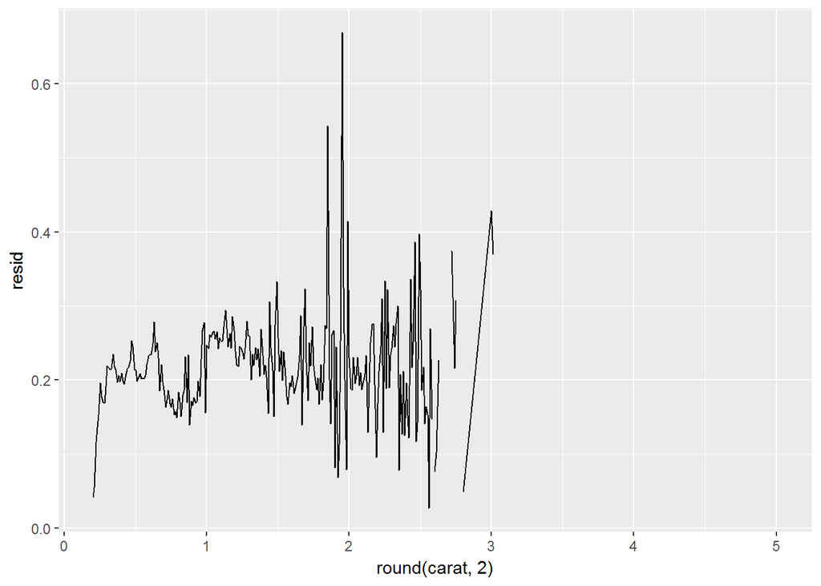

```r
dat$resid <- as.numeric(dat$m4.residuals)
ggplot(aes(y = resid, x = round(carat, 2)), data = dat) +
  geom_line(stat = "summary", fun.y = sd)
```

Evaluate how well the model predicts the BlueNile diamond’s price. Think about the fitted point estimate as well as the 95% CI.

## Final Thoughts

Notes:

Click **KnitHTML** to see all of your hard work and to have an html page of this lesson, your answers, and your notes!